# Aula 1 - Introdução à Regressão Linear

Autor

João Ricardo F. de Lima

Data de Publicação

8 de maio de 2025

# A natureza da análise da regressão

Regressão Linear é ’a principal ferramenta da econometria é a ferramenta estatística que trata do estudo da dependência de uma variável, regressando (Y), em relação a uma ou mais variáveis explicativas (regressores), com o objetivo de estimar e/ou prever o valor médio de Y dados os valores de X.

Apesar da análise de regressão tratar da dependência de uma variável sobre outras variáveis, isto não necessariamente implica “causa”. Uma relação estatística em si não pode logicamente implicar em causa. Para atribuir causalidade deve-se considerar a teoria econômica ou mesmo o senso comum.

# Regressão versus Correlação

Relacionado mas conceitualmente muito diferente é a análise da regressão e de correlação. Na regressão é estimar ou prever o valor médio do regressando (Y) com base nos valores fixos dos regressores (X). Na correlação o objetivo é mensurar o grau de associação linear entre duas variáveis.

As estimativas de correlação podem ser positivas ou negativas. O primeiro caso é quando uma variável cresce, a outra aumenta também. O segundo caso é o inverso.

O coeficiente de correlação de Pearson ($r$) pode ser encontrado pela fórmula:

$$r=\frac{\sum X_iY_i-\frac{\sum X_i-\sum Y_i}{n}}{\Bigg[\sum X_i^2-\frac{(\sum X_i)^2}{n}\Bigg]\Bigg[\sum Y_i^2-\frac{(\sum Y_i)^2}{n}\Bigg]}$$
A ocorrência de um valor de r=0 ou próximo de zero indica que não há correlação linear entre as variáveis, mas pode ocorrer não linear.

As principais características do coeficiente de correlação de Pearson são:

1. Seus valores estão compreendidos entre -1 e 1;
2. Se o coeficiente for positivo, as duas características estudadas tendem a variar no mesmo sentido;
3. Se o sinal for negativo, as duas características estudadas tendem a variar no sentido contrário;
4. A relação entre duas variáveis é tanto mais estreita quanto mais o coeficiente se aproxima de 1 ou de -1;
5. o valor de r é uma estimativa do parâmetro $\rho$ (rho) da mesma forma que a média ($\bar{x}$) é uma estimativa de $\mu$;

# Modelo de Regressão Simples

## Definição do Modelo de Regressão Simples

O modelo de regressão simples pode ser usado para estudar a relação entre duas variáveis. Em outras palavras, quando se pretender analisar como “y” varia quando “x” mudar;

Considere duas variáveis “y” e “x” que representam alguma população. A equação abaixo relaciona as duas variáveis:

$$y=\beta_0+\beta_1x+u$$

A equação acima é válida para a população de interesse e chamada de **modelo de regressão linear simples**. Pode ser também chamada de regressão bivariada ou de duas variáveis.

Quando relacionadas como acima, as variáveis *x* e *y* podem ser denominadas de diversas formas:

Tabela 1: Terminologia para a regressão simples:

| Y | X |
| --- | --- |
| Variável Dependente | Variável Independente |
| Variável Explicada | Variável Explicativa |
| Variável de Resposta | Variável de Controle |
| Variável Prevista | Variável Previsora |
| Regressando | Regressor |

O termo covariável também pode ser usado para x. O mais comum é variável dependente e independente.

A variável *u*, chamada de termo de erro ou resíduo da regressão representa outros fatores, além de x, que afetam y, mas que não sao observados. Se os outros fatores forem mantidos fixos, sua variação é zero, ou seja, $\Delta u=0$. Assim, x tem um efeito linear sobre y:

$$\Delta y=\beta_1 \Delta x \quad se \quad \Delta u=0$$

A variação em y é, simplesmente, $\beta_1$ multiplicado pela variação em x. Isso significa que $\beta_1$ é o **parâmetro de inclinação** da relação entre y e x, mantendo fixos os fatores em u;

O **parâmetro de intercepto** $\beta_0$ é chamado de constante do modelo.

O coeficiente de inclinação mede a taxa (parcial) da mudança no valor médio de y para uma mudança de uma unidade no valor da variável independente, tudo o mais constante;

O termo de erro **u** representa todas aquelas variáveis que não podem estar explícitas no modelo por razões diversas. Contudo, se assume que a influência destas sobre o regressando é insignificante;

Pode-se entender o termo de erro como os fatores não observados que afetam y.

## Derivação das estimativas de Mínimos Quadrados Ordinários (MQO)

Para estimar o Modelo de Regressão Linear, ou seja, encontrar os parâmetros $\beta_0$ e $\beta_1$ da primeira equação acima o método mais usado é o dos Mínimos Quadrados Ordinários (MQO), pois é intuitivamente e matematicamente mais simples;

Dado que um Modelo de Regressão:

$$Y=\widehat{\beta}_0+\widehat{\beta}_1X+\widehat{u}$$

pode ser definido também como:

$$\widehat{Y}=\widehat{\beta}_0+\widehat{\beta}_1X$$

em que o “chápeu” sobre Y, os betas e u enfatiza que os valores são estimativas.

Pode-se reescrever de forma que:

$$Y=\widehat{Y}+\widehat{u}$$

ou ainda:

$$\widehat{u}=Y-\widehat{Y}$$

então, um método bom para se obter as estimativas dos $\beta$s seria fazer com que a soma de todos os erros fosse a menor possível.

Por questões teóricas, o método dos Mínimos Quadrados Ordinários (MQO) minimiza a soma dos erros ao quadrado, dando peso diferente às observações cujo valor estimado esteja mais próximo ou mais distante do valor observado ($Y$);

Assim, o que se precisa é minimizar uma função conhecida como Soma de Quadrados dos Resíduos (SQR):

$$min \sum\widehat{u}^2=\sum(Y-\widehat{\beta}_0-\widehat{\beta}_1X)^2$$

Após a derivação pode-se mostrar que:

$$\hat{\beta_0}=\overline{Y}-\hat{\beta_1}\overline{X}$$

Uma vez que se tenha $\hat{\beta_1}$, dados os valores das médias de Y e X se obtém o valor de $\hat{\beta_0}$.

E ainda pode-se mostrar que:

$$\hat{\beta_1}=\frac{\sum(X-\overline{X})(Y-\overline{Y})}{\sum(X-\overline{X})^2}$$

$$\hat{\beta_1}=\frac{\sum xy}{\sum x^2}$$

com $x=X-\overline{X}$ e $y=Y-\overline{Y}$.

Uma vez determinados os estimadores de intercepto e inclinação de MQO (Mínimos Quadrados Ordinários), se constrói a **reta de regressão de MQO**:

$$\hat{y}=\hat{\beta}_{0}+\hat{\beta}_{1}x$$

A função dada em acima é chamada de função de regressão amostral (FRA), pois ela é uma versão estimada da função de regressão populacional $E(y|x)=\beta_{0}+\beta_1x$. Como a FRA é obtida para determinada amostra de dados, uma amostra diferente irá gerar um intercepto e um coeficiente de inclinação diferentes.

# Estimação de um modelo usando o Python

Para mais informações sobre como usar o Python em análises estatísticas, consulte: http://econfacape.github.io/microeconometria/python

```python
import pandas as pd
import statsmodels.formula.api as smf
import matplotlib.pyplot as plt

# Inserindo os dados
dados = pd.DataFrame({
    'Ano': [1978, 1979, 1980, 1981, 1982, 1983, 1984, 1985, 1986, 1987],
    'Consumo': [16.6, 18.0, 19.6, 18.4, 19.0, 18.6, 19.2, 20.4, 22.2, 21.8],
    'Renda': [21.2, 22.6, 24.8, 23.8, 23.8, 23.0, 24.2, 26.2, 28.2, 29.2]
})
```

```python
# Estatisticas descritivas das variáveis
print(dados[['Consumo', 'Renda']].describe().round(2).T)
```

```
         count   mean   std   min    25%   50%    75%   max
Consumo   10.0  19.38  1.71  16.6  18.45  19.1  20.20  22.2
Renda     10.0  24.70  2.50  21.2  23.20  24.0  25.85  29.2
```

```python
modelo = smf.ols('Consumo ~ Renda', data=dados).fit()
print(modelo.summary())
```

```
                            OLS Regression Results
==============================================================================
Dep. Variable:                Consumo   R-squared:                       0.957
Model:                            OLS   Adj. R-squared:                  0.951
Method:                 Least Squares   F-statistic:                     176.7
Date:                Qui, 08 Mai 2025   Prob (F-statistic):           9.79e-07
Time:                        11:32:38   Log-Likelihood:                -3.3225
No. Observations:                  10   AIC:                             10.65
Df Residuals:                       8   BIC:                             11.25
Df Model:                           1
Covariance Type:            nonrobust
==============================================================================
                 coef    std err          t      P>|t|      [0.025      0.975]
------------------------------------------------------------------------------
Intercept      2.8576      1.249      2.289      0.051      -0.022       5.737
Renda          0.6689      0.050     13.294      0.000       0.553       0.785
==============================================================================
Omnibus:                        1.046   Durbin-Watson:                   2.028
Prob(Omnibus):                  0.593   Jarque-Bera (JB):                0.797
Skew:                          -0.444   Prob(JB):                        0.671
Kurtosis:                       1.939   Cond. No.                         260.
==============================================================================

Notes:
[1] Standard Errors assume that the covariance matrix of the errors is correctly specified.
```

O resultado do modelo estimado é $\hat{Y}=2,8576 + 0,6689X$, em que $Y$ é o consumo e $X$ é a renda.

Matematicamente, o intercepto diz que quando a renda é zero, o consumo esperado é de aproximadamente 2,86 dólares. Contudo, não temos interesse nesta informação.

O $\hat{\beta}$ da inclinação diz que para cada um dólar a mais na renda, o consumo aumenta, em média, 0,6689 dólares.

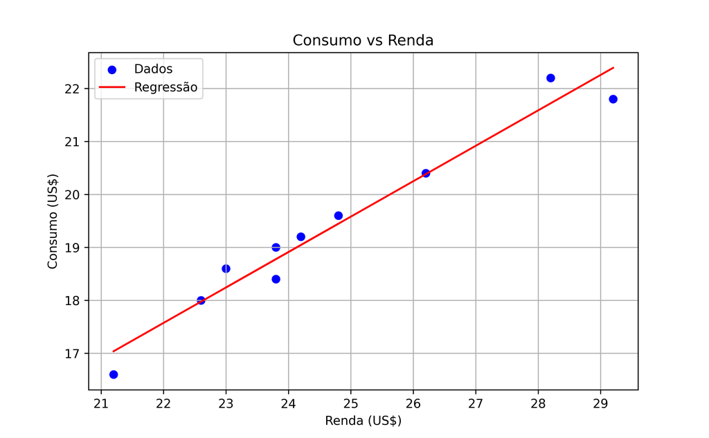

```python
# Gráfico do ajuste
plt.scatter(dados['Renda'], dados['Consumo'], color='blue', label='Dados')
plt.plot(dados['Renda'], modelo.predict(dados), color='red', label='Regressão')
plt.xlabel('Renda (US$)')
plt.ylabel('Consumo (US$)')
plt.title('Consumo vs Renda')
plt.legend()
plt.grid(True)
plt.show()
```

No caso da previsão, pode-se calcular com o modelo estimado se a renda for de US$ 30, por exemplo:

```python
consumo_previsto = modelo.predict(pd.DataFrame({'Renda': [30]}))  # 1 é o valor da constante
print(f"Consumo previsto para renda de $30: {consumo_previsto[0]:.2f}")
```

```
Consumo previsto para renda de $30: 22.93
```

## Análise dos resíduos

```python
# Gerar valores previstos (y_hat)
dados['y_estimado'] = modelo.predict(dados)

# Calcular os resíduos
dados['residuo'] = dados['Consumo'] - dados['y_estimado']
```

```python
# Arredondar para 2 casas decimais
tabela_resultado = dados[['Ano', 'Consumo', 'Renda', 'y_estimado', 'residuo']].round(2)

# Exibir como tabela
print(tabela_resultado.to_string(index=False))
```

```
 Ano  Consumo  Renda  y_estimado  residuo
1978     16.6   21.2       17.04    -0.44
1979     18.0   22.6       17.98     0.02
1980     19.6   24.8       19.45     0.15
1981     18.4   23.8       18.78    -0.38
1982     19.0   23.8       18.78     0.22
1983     18.6   23.0       18.24     0.36
1984     19.2   24.2       19.05     0.15
1985     20.4   26.2       20.38     0.02
1986     22.2   28.2       21.72     0.48
1987     21.8   29.2       22.39    -0.59
```

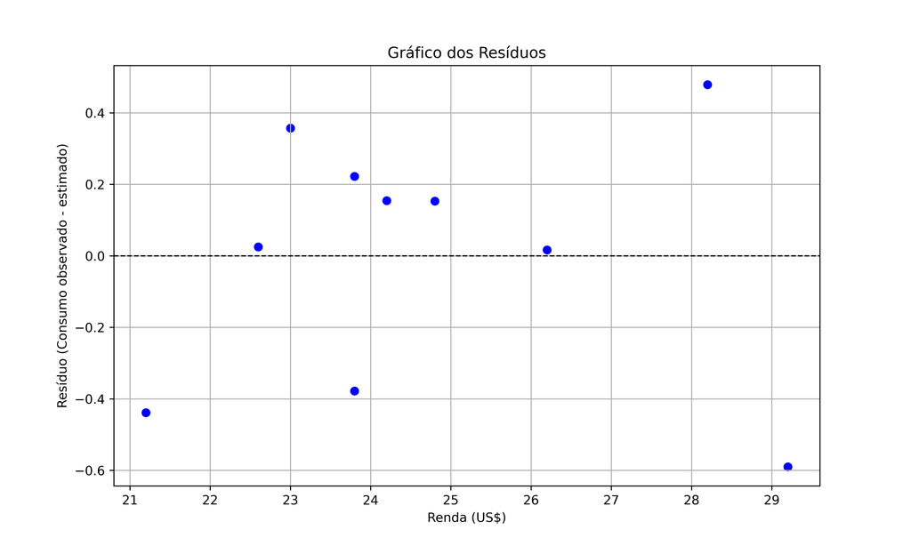

```python
plt.figure(figsize=(10, 6))
plt.axhline(y=0, color='black', linestyle='--', linewidth=1)
plt.scatter(dados['Renda'], dados['residuo'], color='blue')
plt.title('Gráfico dos Resíduos')
plt.xlabel('Renda (US$)')
plt.ylabel('Resíduo (Consumo observado - estimado)')
plt.grid(True)
plt.show()
```